# Project Python Foundations: FoodHub Data Analysis

**Marks: 60**

### Context

The number of restaurants in New York is increasing day by day. Lots of students and busy professionals rely on those restaurants due to their hectic lifestyles. Online food delivery service is a great option for them. It provides them with good food from their favorite restaurants. A food aggregator company FoodHub offers access to multiple restaurants through a single smartphone app.

The app allows the restaurants to receive a direct online order from a customer. The app assigns a delivery person from the company to pick up the order after it is confirmed by the restaurant. The delivery person then uses the map to reach the restaurant and waits for the food package. Once the food package is handed over to the delivery person, he/she confirms the pick-up in the app and travels to the customer's location to deliver the food. The delivery person confirms the drop-off in the app after delivering the food package to the customer. The customer can rate the order in the app. The food aggregator earns money by collecting a fixed margin of the delivery order from the restaurants.

### Objective

The food aggregator company has stored the data of the different orders made by the registered customers in their online portal. They want to analyze the data to get a fair idea about the demand of different restaurants which will help them in enhancing their customer experience. Suppose you are hired as a Data Scientist in this company and the Data Science team has shared some of the key questions that need to be answered. Perform the data analysis to find answers to these questions that will help the company to improve the business.

### Data Description

The data contains the different data related to a food order. The detailed data dictionary is given below.

### Data Dictionary

- order_id: Unique ID of the order
- customer_id: ID of the customer who ordered the food
- restaurant_name: Name of the restaurant
- cuisine_type: Cuisine ordered by the customer
- cost: Cost of the order
- day_of_the_week: Indicates whether the order is placed on a weekday or weekend (The weekday is from Monday to Friday and the weekend is Saturday and Sunday)
- rating: Rating given by the customer out of 5
- food_preparation_time: Time (in minutes) taken by the restaurant to prepare the food. This is calculated by taking the difference between the timestamps of the restaurant's order confirmation and the delivery person's pick-up confirmation.
- delivery_time: Time (in minutes) taken by the delivery person to deliver the food package. This is calculated by taking the difference between the timestamps of the delivery person's pick-up confirmation and drop-off information

### Let us start by importing the required libraries

```python
# import libraries for data manipulation
import numpy as np
import pandas as pd

# import libraries for data visualization
import matplotlib.pyplot as plt
import seaborn as sns

# to restrict float value to 3 decimal places
pd.options.display.float_format="{:,.3f}".format
```

### Understanding the structure of the data

```python
# read the data
df = pd.read_csv('foodhub_order.csv')
# returns the first 5 rows
df.head()
```

|  | order_id | customer_id | restaurant_name | cuisine_type | cost_of_the_order | day_of_the_week | rating | food_preparation_time | delivery_time |
| --- | --- | --- | --- | --- | --- | --- | --- | --- | --- |
| 0 | 1477147 | 337525 | Hangawi | Korean | 30.750 | Weekend | Not given | 25 | 20 |
| 1 | 1477685 | 358141 | Blue Ribbon Sushi Izakaya | Japanese | 12.080 | Weekend | Not given | 25 | 23 |
| 2 | 1477070 | 66393 | Cafe Habana | Mexican | 12.230 | Weekday | 5 | 23 | 28 |
| 3 | 1477334 | 106968 | Blue Ribbon Fried Chicken | American | 29.200 | Weekend | 3 | 25 | 15 |
| 4 | 1478249 | 76942 | Dirty Bird to Go | American | 11.590 | Weekday | 4 | 25 | 24 |

#### Observations:

- **The DataFrame has 9 columns as mentioned in the Data Dictionary. Data in each row corresponds to the order placed by a customer.**

### **Question 1:** How many rows and columns are present in the data? [0.5 mark]

```python
# This gives us the dimension of the data type.
df.shape
print('There are', df.shape[0], 'rows and', df.shape[1], 'columns.')
```

```
There are 1898 rows and 9 columns.
```

#### Observations:

- **This gives us an understanding of the dimension of the data set, There are 1898 rows and 9 columns. using df.tail(), we might be tempted to say there are 1897 rows but the indexing for rows strts from zero(0) so that gives us 1898 rows.**

### **Question 2:** What are the datatypes of the different columns in the dataset? (The info() function can be used) [0.5 mark]

```python
# Use info() to print a concise summary of the DataFrame
df.info()
```

```
<class 'pandas.core.frame.DataFrame'>
RangeIndex: 1898 entries, 0 to 1897
Data columns (total 9 columns):
 #   Column                 Non-Null Count  Dtype
---  ------                 --------------  -----
 0   order_id               1898 non-null   int64
 1   customer_id            1898 non-null   int64
 2   restaurant_name        1898 non-null   object
 3   cuisine_type           1898 non-null   object
 4   cost_of_the_order      1898 non-null   float64
 5   day_of_the_week        1898 non-null   object
 6   rating                 1898 non-null   object
 7   food_preparation_time  1898 non-null   int64
 8   delivery_time          1898 non-null   int64
dtypes: float64(1), int64(4), object(4)
memory usage: 133.6+ KB
```

#### Observations:

**There are 5 numerical columns and 4 object type columns**

### **Question 3:** Are there any missing values in the data? If yes, treat them using an appropriate method. [1 mark]

```python
# The code below helps to check if there are missing values in the data set.
#The isnull checks every single data set and verifies if its a null value (na or nan) and the .sum() syntax sums up the entries as a boolean  variable where True= 1 and False =0
df.isnull().sum()
```

```
order_id                 0
customer_id              0
restaurant_name          0
cuisine_type             0
cost_of_the_order        0
day_of_the_week          0
rating                   0
food_preparation_time    0
delivery_time            0
dtype: int64
```

#### Observations:

- **There are no missing values in the data as the sum of the data for all the columns is equal to zero which indicates no missing value. As such, there is nothing to treat.**

### **Question 4:** Check the statistical summary of the data. What is the minimum, average, and maximum time it takes for food to be prepared once an order is placed? [2 marks]

```python
#The code below gives us a statistical summary of both numerical and categorical variables by using the include='all' and .T transposes the columns for better visualization.
df.describe(include='all').T
```

|  | count | unique | top | freq | mean | std | min | 25% | 50% | 75% | max |
| --- | --- | --- | --- | --- | --- | --- | --- | --- | --- | --- | --- |
| order_id | 1,898.000 | NaN | NaN | NaN | 1,477,495.500 | 548.050 | 1,476,547.000 | 1,477,021.250 | 1,477,495.500 | 1,477,969.750 | 1,478,444.000 |
| customer_id | 1,898.000 | NaN | NaN | NaN | 171,168.478 | 113,698.140 | 1,311.000 | 77,787.750 | 128,600.000 | 270,525.000 | 405,334.000 |
| restaurant_name | 1898 | 178 | Shake Shack | 219 | NaN | NaN | NaN | NaN | NaN | NaN | NaN |
| cuisine_type | 1898 | 14 | American | 584 | NaN | NaN | NaN | NaN | NaN | NaN | NaN |
| cost_of_the_order | 1,898.000 | NaN | NaN | NaN | 16.499 | 7.484 | 4.470 | 12.080 | 14.140 | 22.297 | 35.410 |
| day_of_the_week | 1898 | 2 | Weekend | 1351 | NaN | NaN | NaN | NaN | NaN | NaN | NaN |
| rating | 1898 | 4 | Not given | 736 | NaN | NaN | NaN | NaN | NaN | NaN | NaN |
| food_preparation_time | 1,898.000 | NaN | NaN | NaN | 27.372 | 4.632 | 20.000 | 23.000 | 27.000 | 31.000 | 35.000 |
| delivery_time | 1,898.000 | NaN | NaN | NaN | 24.162 | 4.973 | 15.000 | 20.000 | 25.000 | 28.000 | 33.000 |

#### Observations:

- **The minimum time it takes for food to be prepared is 20.0 minutes.**
- **The average time it takes for food to be prepared is 27.37 minutes.**
- **The maximum time it takes or food to be prepared is 35.0 minutes.**
- **Additionally, the minimum delivery time is 15 minutes, average delivery time is 24.162 minutes and maximum delivery time is 33 minutes from the time delivery person confirms pick up of the order.**
- **Cost of orders is between 4.47 and 35.41**

### **Question 5:** How many orders are not rated? [1 mark]

```python
#The code below gives you a summary of the different values assigned to the orders in terms of ratings as well as orders that were not rated
df.rating.value_counts()
```

```
Not given    736
5            588
4            386
3            188
Name: rating, dtype: int64
```

#### Observations:

- **It can be seen that 736 orders of the total number of orders were not rated.**
- **588 orders received a rating of 5 from different customers.**
- **386 orders received a rating of 4 from different customers.**
- **188 orders received a rating of 3 from different customers.**

### Exploratory Data Analysis (EDA)

### **Question 6:** Explore all the variables and provide observations on their distributions. (Generally, histograms, boxplots, countplots, etc. are used for univariate exploration.) [9 marks]

### **order_id**

```python
# The code below gives us an array of all the elements in the order_id column
df['order_id'].unique()
```

```
array([1477147, 1477685, 1477070, ..., 1477819, 1477513, 1478056],
      dtype=int64)
```

```python
# checking the count of different data types in order_id column
df['order_id'].apply(type).value_counts()
```

```
<class 'int'>    1898
Name: order_id, dtype: int64
```

```python
# This is similar to the information gotten from question 2 and it further confirms that there are no missing values
df['order_id'].nunique()
```

```
1898
```

#### Observations

- **The codes above yielded results about column (order_id)**
- **The unique order_id for 1898 orders were displayed in an array format**
- **The value_counts also tally with the information gotten using df.info which shows that there are no missing values in the data as there 1898 rows**
- **Unique order_id is a numerical variable**

### **customer_id**

```python
# The code below gives us an array of all the elements in the customer_id column
df['customer_id'].unique()
```

```
array([337525, 358141,  66393, ...,  97838, 292602, 397537], dtype=int64)
```

```python
# checking the count of different data types in customer_id column
df['customer_id'].apply(type).value_counts()
```

```
<class 'int'>    1898
Name: customer_id, dtype: int64
```

```python
#to check unique customer_id
df['customer_id'].nunique()
```

```
1200
```

#### Observations

- **The codes above yielded results about column (customer_id)**
- **The customer_id were displayed in array format**
- **The value_counts for customer_id tall with the information gotten using df.info which shows no missing data**
- **The number of unique values in the column cutomer_id is 1200 meaning some customers placed more than a single order**

### **restaurant_name**

```python
# The code below gives us an array of all the elements in the restaurant_name column
df['restaurant_name'].unique()
```

```
array(['Hangawi', 'Blue Ribbon Sushi Izakaya', 'Cafe Habana',
       'Blue Ribbon Fried Chicken', 'Dirty Bird to Go',
       'Tamarind TriBeCa', 'The Meatball Shop', 'Barbounia',
       'Anjappar Chettinad', 'Bukhara Grill',
       'Big Wong Restaurant \x8c_¤¾Ñ¼', 'Empanada Mama (closed)', 'Pylos',
       "Lucky's Famous Burgers", 'Shake Shack', 'Sushi of Gari',
       'RedFarm Hudson', 'Blue Ribbon Sushi',
       'Five Guys Burgers and Fries', 'Tortaria', 'Cafe Mogador',
       'Otto Enoteca Pizzeria', 'Vezzo Thin Crust Pizza',
       'Sushi of Gari 46', 'The Kati Roll Company', 'Klong',
       '5 Napkin Burger', 'TAO', 'Parm', 'Sushi Samba',
       'Haru Gramercy Park', 'Chipotle Mexican Grill $1.99 Delivery',
       'RedFarm Broadway', 'Cafeteria', 'DuMont Burger',
       "Sarabeth's East", 'Hill Country Fried Chicken', 'Bistango',
       "Jack's Wife Freda", "Mamoun's Falafel", 'Prosperity Dumpling',
       'Blue Ribbon Sushi Bar & Grill', 'Westville Hudson',
       'Blue Ribbon Brooklyn', 'Nobu Next Door', 'Osteria Morini',
       'Haandi', 'Benihana', 'Han Dynasty', 'Chote Nawab',
       'Mission Cantina', "Xi'an Famous Foods", 'Rubirosa',
       "Joe's Shanghai \x8e_À\x8eü£¾÷´", 'Bareburger', 'The Odeon',
       'Pongsri Thai', 'Yama Japanese Restaurant', 'Momoya',
       'Balthazar Boulangerie', 'CafÌ© China', 'Boqueria',
       'Song Thai Restaurant & Bar', 'Five Leaves',
       'Pinto Nouveau Thai Bistro', "Amy Ruth's", 'Pepe Giallo',
       'indikitch', 'Yama 49', 'Piccolo Angolo', 'Pepe Rosso To Go',
       "L'Express", 'Amma', 'Delicatessen', "S'MAC",
       "Vanessa's Dumplings", 'Bhatti Indian Grill', 'Taro Sushi',
       'Donburi-ya', 'Hatsuhana', 'Samurai Mama', 'Waverly Diner',
       'Tarallucci e Vino Restaurant', "P.J. Clarke's",
       'Lantern Thai Kitchen', 'ilili Restaurant', 'The Smile',
       "Vanessa's Dumpling House", "Bubby's ", 'Woorijip',
       'Dirty Bird To Go (archived)', 'Haveli Indian Restaurant',
       'Dos Caminos', 'da Umberto', 'Sushi of Gari Tribeca',
       'Burger Joint', 'Room Service', "Sarabeth's Restaurant",
       'Xe May Sandwich Shop', 'Hibino', 'Mira Sushi', 'Melt Shop',
       'J. G. Melon', 'Hummus Place', 'Saravanaa Bhavan',
       'Friend of a Farmer', 'The Loop', 'Balade', 'Posto',
       'Terakawa Ramen', 'Kambi Ramen House', 'Wo Hop Restaurant',
       'Spice Thai', "Dickson's Farmstand Meats",
       'UVA Wine Bar & Restaurant', 'Serafina Fabulous Pizza',
       'Gaia Italian Cafe', 'Chola Eclectic Indian Cuisine',
       'Hot Kitchen', 'Junoon', 'Ravagh Persian Grill', 'Rohm Thai',
       'Dig Inn Seasonal Market', 'Olea', 'Cho Dang Gol',
       'El Parador Cafe', 'Socarrat Paella Bar',
       "Don's Bogam BBQ & Wine Bar", 'Alidoro', "Tony's Di Napoli",
       'Cipriani Le Specialita', 'Sushi Choshi', 'Kanoyama', 'V-Nam Cafe',
       'Zero Otto Nove', 'Dos Caminos Soho', 'Go! Go! Curry!',
       'La Follia', 'Izakaya Ten', '12 Chairs', 'Philippe Chow',
       'The MasalaWala', 'brgr', "Carmine's", 'Asuka Sushi', 'Aurora',
       "Sarabeth's", 'Crema Restaurante', "Big Daddy's",
       'Moonstruck on Second', 'Cafe de La Esquina', 'Olive Garden',
       '67 Burger', 'Tres Carnes', "Schnipper's Quality Kitchen",
       'Nha Trang One', 'Market Table', 'Galli Restaurant',
       'Hampton Chutney Co.', 'Byblos Restaurant',
       'Grand Sichuan International', 'Le Grainne Cafe', 'Il Bambino',
       'Kori Restaurant and Bar', 'DespaÌ±a', 'Lamarca Pasta',
       'Lucky Strike', "Paul & Jimmy's", 'Hunan Manor', "Coppola's East",
       'Emporio', 'Wa Jeal', 'Le Zie 2000 Trattoria', 'Rye House',
       "Hiroko's Place", 'Frank Restaurant', "Sarabeth's West",
       "'wichcraft"], dtype=object)
```

```python
# checking the count of different data types in restaurant_name column
df['restaurant_name'].apply(type).value_counts()
```

```
<class 'str'>    1898
Name: restaurant_name, dtype: int64
```

```python
#to check unique restaurant_name
df['restaurant_name'].nunique()
```

```
178
```

#### Observations

- **The codes above yielded results about column (restaurant_name)**
- **The restaurant_name were displayed in array format**
- **The value_counts for restaurant_name with the information gotten using df.info which shows no missing data**
- **The number of unique values in the column restaurant_name is 178 meaning more than one order went to different restaurants**

### **cuisine_type**

```python
# The code below gives us an array of all the elements in the cuisine_type column
df['cuisine_type'].unique()
```

```
array(['Korean', 'Japanese', 'Mexican', 'American', 'Indian', 'Italian',
       'Mediterranean', 'Chinese', 'Middle Eastern', 'Thai', 'Southern',
       'French', 'Spanish', 'Vietnamese'], dtype=object)
```

```python
# checking the count of different data types in cuisine_type column
df['cuisine_type'].apply(type).value_counts()
```

```
<class 'str'>    1898
Name: cuisine_type, dtype: int64
```

```python
#to check number of unique cuisine_type
df['cuisine_type'].nunique()
```

```
14
```

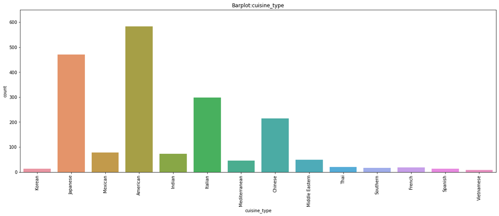

```python
plt.figure(figsize = (20,7))# figure to be drawn with a width of 20inches and an height of 7inches
plt.title('Barplot:cuisine_type') #title of the plot
plt.ylim(0,650) #limit on the y-axis running from 0 to 650
sns.countplot(data = df, x = 'cuisine_type');
plt.xlabel('cuisine_type') #x-axis title
plt.xticks(rotation=90); #rotating the x-labels by 90 degrees for better orientation
```

#### Observations

- **The codes above yielded results about column (cuisine_type)**
- **The different cuisine_type were displayed in array format**
- **The value_counts for cuisine_type with the information gotten using df.info which shows no missing data**
- **The number of unique values in the column cuisine_type is 14 which means we had a distribution of customers placing orders across 14 cuisine types**
- **Majority of the customers ordered for American cuisine**
- **Japanese, Italian and Chinese cuisines were the 2nd, 3rd and 4th most ordered cuisines respectively**
- **Vietnamese cuisine was the least ordered cuisine**

### **cost_of_the_order**

```python
# The code below gives us an array of all the elements in the cost_of_the_order column
df['cost_of_the_order'].unique()
```

```
array([30.75, 12.08, 12.23, 29.2 , 11.59, 25.22,  6.07,  5.97, 16.44,
        7.18,  5.92,  8.1 , 24.3 , 11.3 , 12.13, 16.2 , 16.98, 33.03,
       14.12, 24.2 , 15.91, 29.1 ,  8.92, 15.86, 21.88, 14.02,  9.17,
       12.18, 31.33, 29.05,  8.39,  9.12, 15.47, 16.01, 29.83, 19.89,
       19.35, 33.22, 24.25, 22.75,  6.74, 13.78, 16.93, 29.39, 20.23,
       14.6 ,  6.79, 31.38,  8.34, 12.46, 14.55, 32.93,  8.  , 13.05,
        5.67, 29.29, 16.15, 13.34,  9.75,  6.69,  4.75, 12.56, 21.2 ,
       19.31, 16.3 , 25.27, 14.79,  5.72,  9.22, 16.39, 17.03, 21.83,
       31.29, 11.83, 22.26, 20.47, 15.81, 22.36,  8.68, 12.9 , 29.15,
        7.86, 16.1 , 12.95, 11.69, 12.32, 14.99, 10.38,  9.65,  5.77,
        9.56, 29.34, 11.16, 14.07, 22.8 , 15.23, 16.49,  8.83, 16.25,
       16.83, 10.24, 19.4 , 13.97, 13.  ,  8.49, 20.18, 19.59, 16.11,
       12.27, 13.39,  9.02, 15.33, 31.43, 29.35, 15.28,  9.6 ,  8.88,
       15.96,  8.05,  8.54,  7.23, 19.69,  9.27,  8.97, 11.64, 13.15,
        9.41,  9.07, 14.46,  6.7 , 19.45, 12.22, 29.25, 16.05, 17.08,
       32.98, 13.73, 14.31, 14.7 , 15.52,  6.11, 21.93, 15.76,  9.46,
       12.61, 22.85, 16.06, 21.39,  8.25, 14.94, 14.26, 21.34, 14.16,
        5.68, 15.57, 14.45,  8.15,  8.78,  8.59, 15.62,  5.87,  6.01,
        9.85,  6.84,  5.82,  7.96,  9.7 ,  4.85,  6.06, 12.66,  6.02,
        7.08, 12.37, 14.84, 22.31, 13.1 , 14.75, 24.35, 25.17,  9.26,
        9.55, 13.92,  4.66, 13.87,  7.61, 15.72,  8.35, 14.21, 14.65,
        4.71,  8.63, 13.68, 11.93, 35.41,  6.64, 10.72,  8.73, 16.78,
        5.58, 13.63, 29.54, 29.49, 15.04, 18.24,  4.47,  8.98, 15.71,
        8.93,  9.51,  9.61,  7.38, 13.19, 10.82,  6.26,  8.2 ,  7.33,
       12.71,  5.63, 17.07,  5.48, 22.12, 15.77,  6.45, 11.79, 11.98,
       20.32, 28.57, 22.07, 21.29, 14.41, 29.88,  4.8 , 10.14,  8.44,
       16.54,  7.71, 29.78, 31.86, 19.98, 12.42, 12.52, 15.38,  8.3 ,
       13.24,  8.01, 29.68,  9.32, 12.51,  5.34,  6.4 , 19.3 , 17.85,
       16.88, 13.77,  5.73, 11.84, 15.67, 13.58, 33.18,  6.55, 20.52,
       28.62, 15.18, 29.3 , 12.81, 29.44, 11.11, 14.5 , 22.02, 11.88,
       33.32, 18.43, 12.47, 20.13, 20.57, 15.09, 19.74, 18.04, 31.67,
        5.05,  7.03, 14.8 , 12.17,  7.28, 15.13,  7.81, 16.74,  9.31,
       21.25, 31.87, 19.02, 34.19,  5.53, 22.46, 29.73, 10.43, 19.5 ,
        4.9 , 15.37,  7.67,  7.91, 13.53, 33.37, 19.6 , 13.48, 20.71,
       20.61,  7.66, 10.86,  7.95, 20.86, 29.59])
```

```python
# checking the count of different data types in cost_of_the_order column
df['cost_of_the_order'].apply(type).value_counts()
```

```
<class 'float'>    1898
Name: cost_of_the_order, dtype: int64
```

```python
#to check number of unique cost_of_the_order
df['cost_of_the_order'].nunique()
```

```
312
```

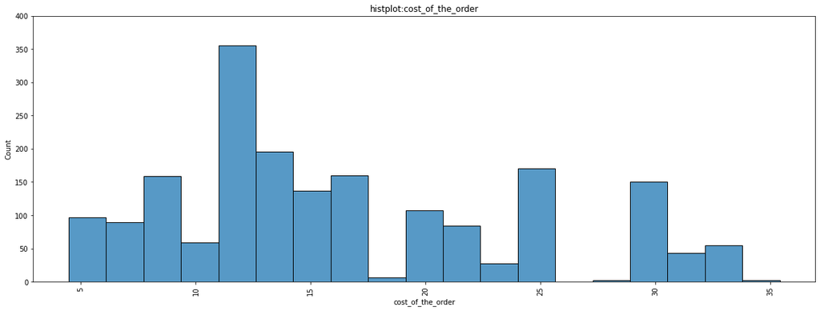

```python
plt.figure(figsize = (20,7))# figure to be drawn with a width of 20inches and an height of 7inches
plt.title('histplot:cost_of_the_order') #title of the plot
plt.ylim(0,400) #limit on the y-axis running from 0 to 400
sns.histplot(data = df, x = 'cost_of_the_order');
plt.xlabel('cost_of_the_order') #x-axis title
plt.xticks(rotation=90); #rotating the x-labels by 90 degrees for better orientation
```

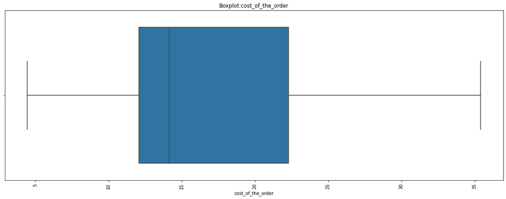

```python
plt.figure(figsize = (20,7))# figure to be drawn with a width of 20inches and an height of 7inches
plt.title('Boxplot:cost_of_the_order') #title of the plot
sns.boxplot(data = df, x = 'cost_of_the_order');
plt.xlabel('cost_of_the_order') #x-axis title
plt.xticks(rotation=90); #rotating the x-labels by 90 degrees for better orientation
```

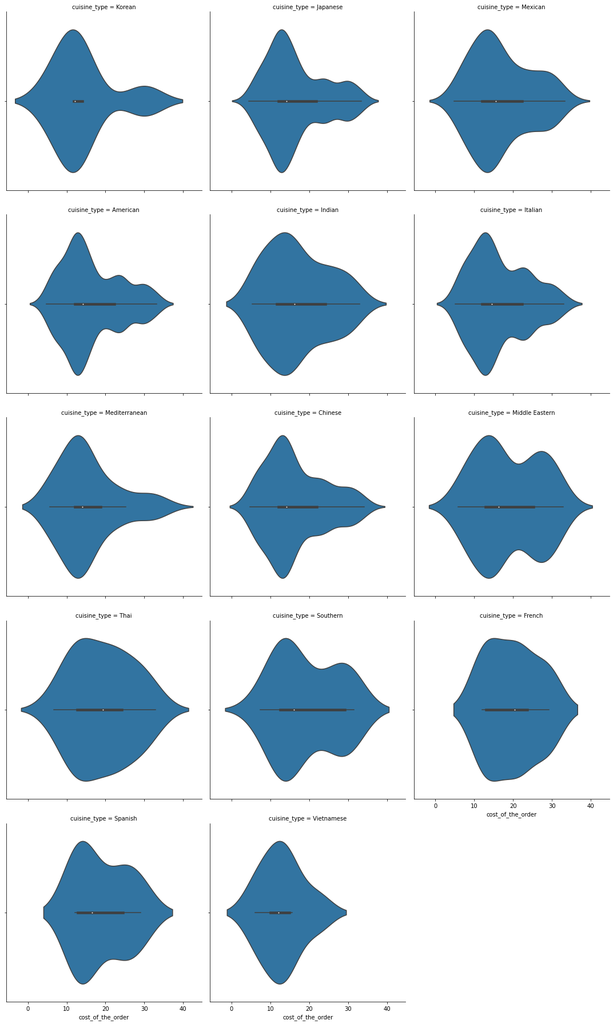

```python
sns.catplot(x='cost_of_the_order',
            col='cuisine_type',
            data=df,
            col_wrap=3,# 3 plots per line
            kind="violin");
```

### **day_of_the_week**

```python
# The code below gives us an array of all the elements in the day_of_the_week column
df['day_of_the_week'].unique()
```

```
array(['Weekend', 'Weekday'], dtype=object)
```

```python
# checking the count of different data types in day_of_the_week column
df['day_of_the_week'].apply(type).value_counts()
```

```
<class 'str'>    1898
Name: day_of_the_week, dtype: int64
```

```python
#to check number of unique day_of_the_week
df['day_of_the_week'].nunique()
```

```
2
```

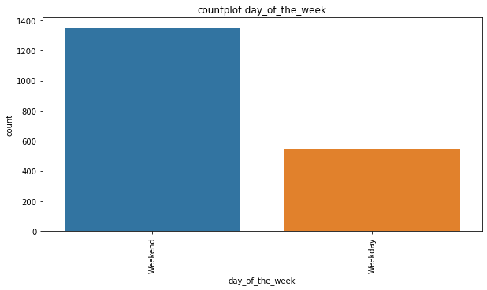

```python
plt.figure(figsize = (10,5))# figure to be drawn with a width of 10inches and an height of 5inches
plt.title('countplot:day_of_the_week') #title of the plot
sns.countplot(data = df, x ='day_of_the_week') ;
plt.xlabel('day_of_the_week') #x-axis title
plt.xticks(rotation=90); #rotating the x-labels by 90 degrees for better orientation
```

#### Observations

- **The codes above yielded results about column (day_of_the_week)**
- **The different (days_of_the_week) were displayed in array format**
- **The value_counts for day_of_the_week with the information gotten using df.info shows no missing data**
- **The number of unique values in the column day_of_the_week is 2 which means different orders were either placed during weekdays or weekends**
- **Majority of the orders were placed during weekends**

### **rating**

```python
# to check the unique values
df['rating'].nunique()
```

```
4
```

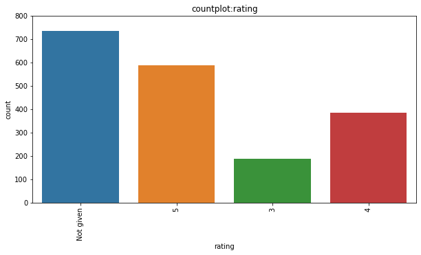

```python
plt.figure(figsize = (10,5))# figure to be drawn with a width of 10inches and an height of 7inches
plt.title('countplot:rating') #title of the plot
plt.ylim(0,800) #limit on the y-axis running from 0 to 800
sns.countplot(data = df, x = 'rating');
plt.xlabel('rating') #x-axis title
plt.xticks(rotation=90); #rotating the x-labels by 90 degrees for better orientation
```

#### Observation

- **Most orders (about 730) didn't receive any rating from the customers.**
- **Of all the remaining rated orders, the highest numbers of orders (about 590) received a rating of 5**
- **About 190 orders from the countplot received a rating of 3**
- **About 390 orders from the countplot received a rating of 4**

### **food_preparation_time**

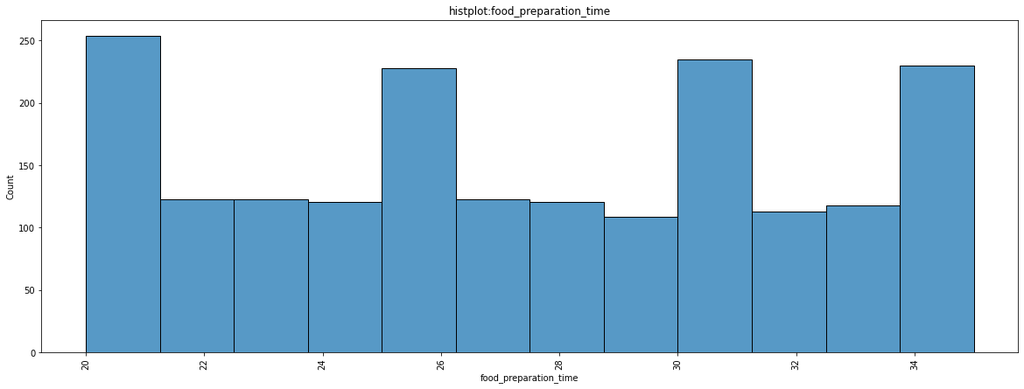

```python
plt.figure(figsize = (20,7))# figure to be drawn with a width of 20inches and an height of 7inches
plt.title('histplot:food_preparation_time') #title of the plot
sns.histplot(data = df, x = 'food_preparation_time');
plt.xlabel('food_preparation_time') #x-axis title
plt.xticks(rotation=90); #rotating the x-labels by 90 degrees for better orientation
```

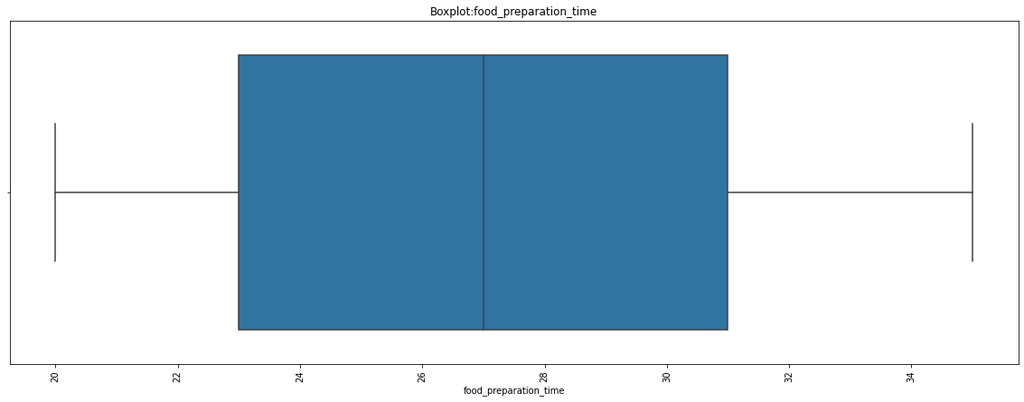

```python
plt.figure(figsize = (20,7))# figure to be drawn with a width of 20inches and an height of 7inches
plt.title('Boxplot:food_preparation_time') #title of the plot
sns.boxplot(data = df, x = 'food_preparation_time');
plt.xlabel('food_preparation_time') #x-axis title
plt.xticks(rotation=90); #rotating the x-labels by 90 degrees for better orientation
```

#### Observation

- **Food preparation time has a uniform distribution as seem from the histogram and the box plot**
- **The median food preparation time is 27 minutes as seen from the box plot**
- **The minimum food preparation time is 20 minutes**
- **The maximum food preparation time is 35 minutes**

### **delivery_time**

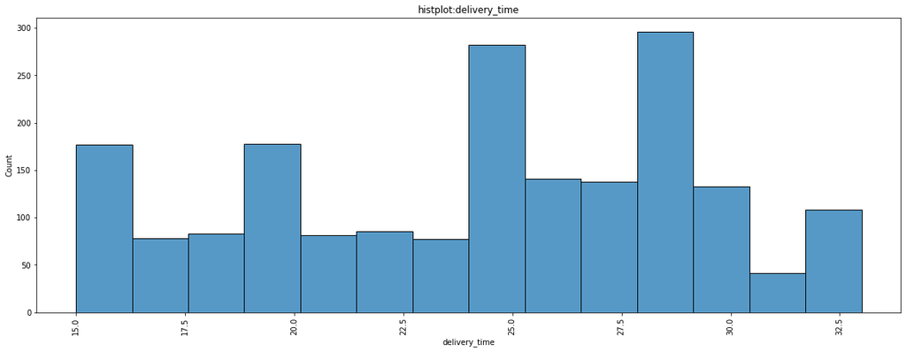

```python
plt.figure(figsize = (20,7))# figure to be drawn with a width of 20inches and an height of 7inches
plt.title('histplot:delivery_time') #title of the plot
sns.histplot(data = df, x = 'delivery_time');
plt.xlabel('delivery_time') #x-axis title
plt.xticks(rotation=90); #rotating the x-labels by 90 degrees for better orientation
```

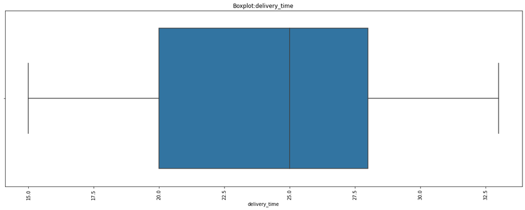

```python
plt.figure(figsize = (20,7))# figure to be drawn with a width of 20inches and an height of 7inches
plt.title('Boxplot:delivery_time') #title of the plot
sns.boxplot(data = df, x = 'delivery_time');
plt.xlabel('delivery_time') #x-axis title
plt.xticks(rotation=90); #rotating the x-labels by 90 degrees for better orientation
```

### **Question 7**: Which are the top 5 restaurants in terms of the number of orders received? [1 mark]

```python
# Get top 5 restaurants with highest number of orders
df['restaurant_name']. value_counts().head()
```

```
Shake Shack                  219
The Meatball Shop            132
Blue Ribbon Sushi            119
Blue Ribbon Fried Chicken     96
Parm                          68
Name: restaurant_name, dtype: int64
```

### Observations:

**The top 5 restaurants with the highest number of orders are**

1. **Shake Shack with 219 orders**
2. **Meatball shop with 132 orders**
3. **Blue Ribbon Sushi with 119 orders**
4. **Blue Ribbon Fried Chicken with 96 orders**
5. **Parm with 68 orders**

### **Question 8**: Which is the most popular cuisine on weekends? [1 mark]

```python
df_weekend = df[df['day_of_the_week'] == 'Weekend']#To create a subset of the days of the week for weekends
df_weekend['cuisine_type'].value_counts()#gives the number of orders made on weekends for different cuisines
```

```
American          415
Japanese          335
Italian           207
Chinese           163
Mexican            53
Indian             49
Mediterranean      32
Middle Eastern     32
Thai               15
French             13
Korean             11
Southern           11
Spanish            11
Vietnamese          4
Name: cuisine_type, dtype: int64
```

```python
df_weekday = df[df['day_of_the_week'] == 'Weekday']#To create a subset of the days of the week for weekday
df_weekday['cuisine_type'].value_counts()#gives the number of orders made on weekday for different cuisines
```

```
American          169
Japanese          135
Italian            91
Chinese            52
Mexican            24
Indian             24
Middle Eastern     17
Mediterranean      14
Southern            6
French              5
Thai                4
Vietnamese          3
Korean              2
Spanish             1
Name: cuisine_type, dtype: int64
```

#### Observations:

**The most popular cuisine on weekends is the American cuisine with the highest number of observations (415).**

### **Question 9**: What percentage of the orders cost more than 20 dollars? [2 marks]

```python
df_greater_than_20 = df[df['cost_of_the_order']>20] # creating or definining a new variable df_greater_than_20
print(df_greater_than_20.shape[0])
percentage = (df_greater_than_20.shape[0] / df.shape[0]) * 100 # to find the percentage of the total orders
print(round(percentage,1), '%') #rounds the percentage to 1decimal place
```

```
555
29.2 %
```

#### Observations:

- **The number of total orders with cost above 20 dollars is 555**
- **The percentage of orders above 20 dollars is 29.2%**

### **Question 10**: What is the mean order delivery time? [1 mark]

```python
mean_del_time = df['delivery_time'].mean() ## defines a new variable called mean_delivery_time and finds the mean from the delivery_time column
print(round(mean_del_time, 1), 'minutes')
```

```
24.2 minutes
```

#### Observations:

**The mean delivery time is 24.2 minutes**

### **Question 11:** The company has decided to give 20% discount vouchers to the top 5 most frequent customers. Find the IDs of these customers and the number of orders they placed. [1 mark]

```python
df['customer_id'].value_counts().head()
```

```
52832     13
47440     10
83287      9
250494     8
259341     7
Name: customer_id, dtype: int64
```

#### Observations:

**The top 5 customers and their id is given below**

### **Question 12**: Perform a multivariate analysis to explore relationships between the important variables in the dataset. (It is a good idea to explore relations between numerical variables as well as relations between numerical and categorical variables) [10 marks]

#### **Cuisine vs Cost of the order**

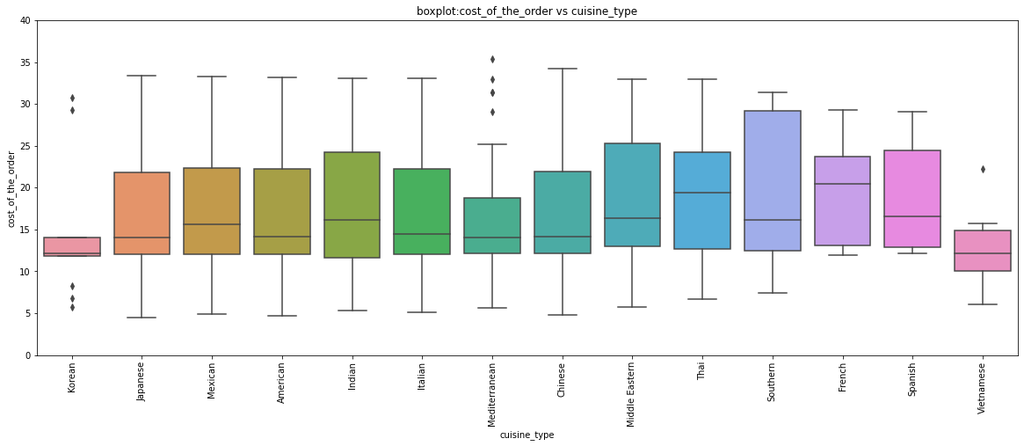

```python
plt.figure(figsize=(20,7)) # figure to be drawn with a width of 20inches and an height of 7inches
plt.title('boxplot:cost_of_the_order vs cuisine_type') #title of the plot
plt.ylim(0,40) #limit on the y-axis running from 0 to 40
sns.boxplot(x = "cuisine_type", y = "cost_of_the_order", data = df);
plt.xticks(rotation = 90);  #rotating the x-labels by 90 degrees for better orientation
```

#### Observations:

- **Outliers exist for the korean, Mediterranean and vietnamese cuisine types**
- **Even though the cost of majority of the orders for the korean cuisine type ranges between 6 and 14, some customers paid a high cost for the korean cusine worth between 29 and 31**
- **Some customers also paid very high prices for the mediterranean cuisine type to the tune of 36**
- **Thai and French cuisine types are left skewed form the box plot which indicates that most orders placed for both cuisine types were between the price range (cost_of_order) of 6 and 22**

#### **Cuisine vs food preparation time**

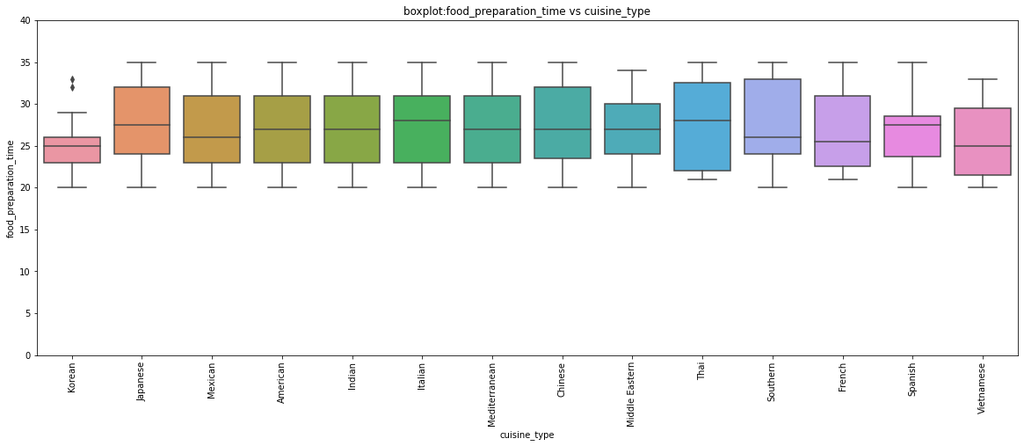

```python
plt.figure(figsize=(20,7)) # figure to be drawn with a width of 20inches and an height of 7inches
plt.title('boxplot:food_preparation_time vs cuisine_type') #title of the plot
plt.ylim(0,40) #limit on the y-axis running from 0 to 40
sns.boxplot(x = "cuisine_type", y = "food_preparation_time", data = df);
plt.xticks(rotation = 90);
```

#### **day_of_the_week vs delivery_time**

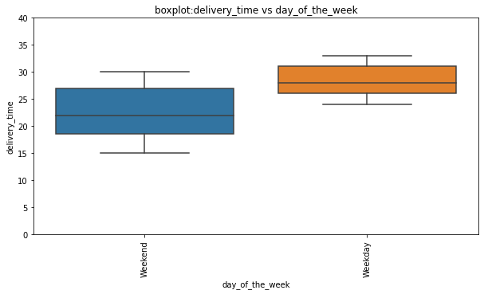

```python
plt.figure(figsize=(10,5)) # figure to be drawn with a width of 10inches and an height of 5inches
plt.title('boxplot:delivery_time vs day_of_the_week') #title of the plot
plt.ylim(0,40) #limit on the y-axis running from 0 to 40
sns.boxplot(x = "day_of_the_week", y = "delivery_time", data = df);
plt.xticks(rotation = 90);
```

#### Observations:

- **Distributions for day_of_the_week vs delivery_time for both weekends and weekdays are slightly skewed to the right**
- **Majority of the orders placed during weekends were delivered faster and in a shorter time than orders placed during weekdays.**
- **The fastest delivery time for weekend orders is 15 minutes while that for weekdays is around 23.75 minutes**
- **For both weekend and weekday orders, the maximum delivery time ranges from 30 to 33 minutes**

### **To obtain revenue generated by the top 5 companies**

```python
# using the groupby function, the code groups restaurant name and cost of all orders placed to the restaurant and sorts it from highest to lowest for the top 5 restaurant
df.groupby(['restaurant_name'])['cost_of_the_order'].sum().sort_values(ascending = False).head()
```

```
restaurant_name
Shake Shack                 3,579.530
The Meatball Shop           2,145.210
Blue Ribbon Sushi           1,903.950
Blue Ribbon Fried Chicken   1,662.290
Parm                        1,112.760
Name: cost_of_the_order, dtype: float64
```

#### Observations:

- **Shake shack made the highest sales with revenue of about $3580**
- **The meatball Shop made the second highest sales with revenue of about $2145**
- **Blue Ribbon Sushi made sales with revenue of about $1903 in third position**
- **Blue Ribbon Fried Chicken mad sales with revenue of about $1662**
- **Parm made sales with revenue of about $1112**

#### **rating vs delivery_time**

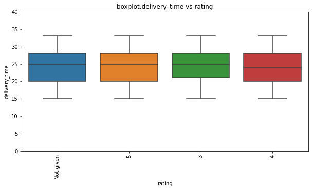

```python
plt.figure(figsize=(10,5)) # figure to be drawn with a width of 10inches and an height of 5inches
plt.title('boxplot:delivery_time vs rating') #title of the plot
plt.ylim(0,40) #limit on the y-axis running from 0 to 40
sns.boxplot(x = "rating", y = "delivery_time", data = df);
plt.xticks(rotation = 90);
```

#### Observations:

- **For orders with a rating of 4, the distribution from the box plot is uniformly distributed while other rated orders (Not given, 3 and 5 have a left skewed distribution**
- **The distribution for orders (not rated) and orders (rated 5) based on delivery time are exactly alike from the plot with a median delivery time of 25 minutes and a minimu and maximum delivery time of 15 minutes and around 33 minutes respectively.**

#### **rating vs food_preparation_time**

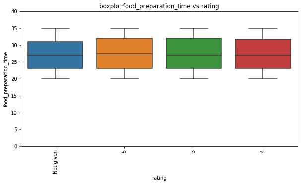

```python
plt.figure(figsize=(10,5)) # figure to be drawn with a width of 10inches and an height of 5inches
plt.title('boxplot:food_preparation_time vs rating') #title of the plot
plt.ylim(0,40) #limit on the y-axis running from 0 to 40
sns.boxplot(x = "rating", y = "food_preparation_time", data = df);
plt.xticks(rotation = 90);
```

#### Observations:

- **For orders with a rating of 5, the distribution from the box plot is uniformly distributed while other rated orders (Not given, 3 and 4 have a slightly right skewed distribution**
- **For orders rated 5, 50% of the orders were prepared between 20 to 27 minutes while the remaining 50% of the orders were prepared between 27 and 35 minutes**
- **For orders rated 3, 75% of the orders were prepared between 20 and 32 minutes**

#### **rating vs cost_of_the_order**

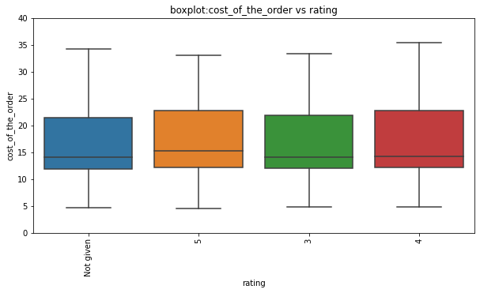

```python
plt.figure(figsize=(10,5)) # figure to be drawn with a width of 10inches and an height of 5inches
plt.title('boxplot:cost_of_the_order vs rating') #title of the plot
plt.ylim(0,40) #limit on the y-axis running from 0 to 40
sns.boxplot(x = "rating", y = "cost_of_the_order", data = df);
plt.xticks(rotation = 90);
```

#### Correlation among variables

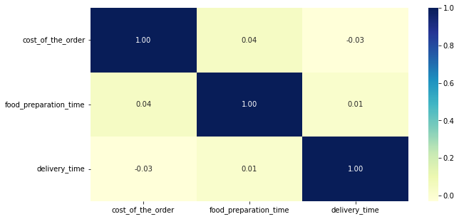

```python
#Heat map of all the numerical variables
plt.figure(figsize=(10, 5)) # figure to be drawn with a width of 10inches and an height of 5inches
#annot=true to display the correclation values in the grid, fmt=.2f to show 2 decimal places and cmap is set to show grid colours of yellow,green and blue
sns.heatmap(data=df[['cost_of_the_order','food_preparation_time', 'delivery_time']].corr(), annot=True, fmt=".2f", cmap='YlGnBu');
```

#### Observations:

- **The correlations between variables as seen from the heatmap are very week between two different variables**
- **There is a negative correlation between delivery time and costof the order**
- **There is a positive correlation between cost of the order and food preparation time. There is also a positive correlation between delivery time and food preparation time.**

#### Correlation between delivery_time and cost_of_the_order

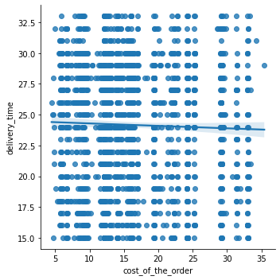

```python
sns.lmplot(data=df,x= 'cost_of_the_order', y= 'delivery_time')
```

#### Observations:

- **The only observation here shows that the line of best fit has a negative slope which correlates to the -0.03 as shown from the heatmap**

### **Question 13:** The company wants to provide a promotional offer in the advertisement of the restaurants. The condition to get the offer is that the restaurants must have a rating count of more than 50 and the average rating should be greater than 4. Find the restaurants fulfilling the criteria to get the promotional offer. [3 marks]

```python
# Filter the rated restaurants
df_rated = df[df['rating'] != 'Not given'].copy()
#Convert rating column from object to integer because some orders were listed as "not rated" which is an object
df_rated['rating'] = df_rated['rating'].astype('int')
# Create a dataframe that contains the restaurant names with their rating counts
df_rating_count = df_rated.groupby(['restaurant_name'])['rating'].count().sort_values(ascending = False).reset_index()
df_rating_count.head()
```

|  | restaurant_name | rating |
| --- | --- | --- |
| 0 | Shake Shack | 133 |
| 1 | The Meatball Shop | 84 |
| 2 | Blue Ribbon Sushi | 73 |
| 3 | Blue Ribbon Fried Chicken | 64 |
| 4 | RedFarm Broadway | 41 |

```python
# define a new variable called rest_names with rating counts more than 50
rest_names = df_rating_count[df_rating_count['rating']>50]['restaurant_name']
# to get the data of restaurants that have rating count more than 50 by assigning them a new variable name df_mean_4
df_mean_4 = df_rated[df_rated['restaurant_name'].isin(rest_names)].copy()
#using groupby function to find the mean rating of restaurants that meet the above criteria
df_mean_4.groupby(['restaurant_name'])['rating'].mean().sort_values(ascending = False).reset_index().dropna()
```

|  | restaurant_name | rating |
| --- | --- | --- |
| 0 | The Meatball Shop | 4.512 |
| 1 | Blue Ribbon Fried Chicken | 4.328 |
| 2 | Shake Shack | 4.278 |
| 3 | Blue Ribbon Sushi | 4.219 |

```python
df.head()
```

|  | order_id | customer_id | restaurant_name | cuisine_type | cost_of_the_order | day_of_the_week | rating | food_preparation_time | delivery_time |
| --- | --- | --- | --- | --- | --- | --- | --- | --- | --- |
| 0 | 1477147 | 337525 | Hangawi | Korean | 30.750 | Weekend | Not given | 25 | 20 |
| 1 | 1477685 | 358141 | Blue Ribbon Sushi Izakaya | Japanese | 12.080 | Weekend | Not given | 25 | 23 |
| 2 | 1477070 | 66393 | Cafe Habana | Mexican | 12.230 | Weekday | 5 | 23 | 28 |
| 3 | 1477334 | 106968 | Blue Ribbon Fried Chicken | American | 29.200 | Weekend | 3 | 25 | 15 |
| 4 | 1478249 | 76942 | Dirty Bird to Go | American | 11.590 | Weekday | 4 | 25 | 24 |

#### Observations:

- **The Meatball shop has the highest mean rating which means a lot of customers that placed orders from the meatball shop rated the services of the meat ball shop highly**
- **Using df.head() ,it shows that the original column (rating) still has its elements preserved from the initial data frame**

### **Question 14:** The company charges the restaurant 25% on the orders having cost greater than 20 dollars and 15% on the orders having cost greater than 5 dollars. Find the net revenue generated by the company across all orders. [3 marks]

```python
#determination of the revenue using if and elif statements to satisfy 2 conditions
def compute_rev(x):
    if x > 20:
        return x*0.25
    elif x > 5:
        return x*0.15
    else:
        return x*0

df['Revenue'] = df['cost_of_the_order'].apply(compute_rev) #This adds another column to the data frame with the variable 'Revenue'
df.head(10)
```

|  | order_id | customer_id | restaurant_name | cuisine_type | cost_of_the_order | day_of_the_week | rating | food_preparation_time | delivery_time | Revenue |
| --- | --- | --- | --- | --- | --- | --- | --- | --- | --- | --- |
| 0 | 1477147 | 337525 | Hangawi | Korean | 30.750 | Weekend | Not given | 25 | 20 | 7.688 |
| 1 | 1477685 | 358141 | Blue Ribbon Sushi Izakaya | Japanese | 12.080 | Weekend | Not given | 25 | 23 | 1.812 |
| 2 | 1477070 | 66393 | Cafe Habana | Mexican | 12.230 | Weekday | 5 | 23 | 28 | 1.835 |
| 3 | 1477334 | 106968 | Blue Ribbon Fried Chicken | American | 29.200 | Weekend | 3 | 25 | 15 | 7.300 |
| 4 | 1478249 | 76942 | Dirty Bird to Go | American | 11.590 | Weekday | 4 | 25 | 24 | 1.738 |
| 5 | 1477224 | 147468 | Tamarind TriBeCa | Indian | 25.220 | Weekday | 3 | 20 | 24 | 6.305 |
| 6 | 1477894 | 157711 | The Meatball Shop | Italian | 6.070 | Weekend | Not given | 28 | 21 | 0.910 |
| 7 | 1477859 | 89574 | Barbounia | Mediterranean | 5.970 | Weekday | 3 | 33 | 30 | 0.895 |
| 8 | 1477174 | 121706 | Anjappar Chettinad | Indian | 16.440 | Weekday | 5 | 21 | 26 | 2.466 |
| 9 | 1477311 | 39705 | Bukhara Grill | Indian | 7.180 | Weekday | 5 | 29 | 26 | 1.077 |

```python
# to get the summation of the revenue generated by the company from all restaurants is to sum the revenue column
total_rev = df['Revenue'].sum()
print(total_rev)
```

```
6166.303
```

#### Observations:

- **Total revenue generated by the company form all the restaurants is around 6166 dollars**

### **Question 15:** The company wants to analyze the total time required to deliver the food. What percentage of orders take more than 60 minutes to get delivered from the time the order is placed? (The food has to be prepared and then delivered.) [2 marks]

```python
# total time required to deliver food is an addition of total preparation time plus delivery time
df['total_time'] = df['food_preparation_time'] + df['delivery_time']
df_greater_than_60_minutes = df[df['total_time']>60] # creating or definining a new variable df_greater_than_60_minutes
print(df_greater_than_60_minutes.shape[0]) #to get the number of orders that requires more than 60 minutes to prepare
percentage = (df_greater_than_60_minutes.shape[0] / df.shape[0]) * 100 # to find the percentage of the total orders requiring more than 60 minutes to prepare
print(round(percentage,1), '%') #rounds the percentage to 1decimal place
```

```
200
10.5 %
```

#### Observations:

- **Of the 1898 orders, 200 orders require more than 60minutes as total time to get delivered to the customer**
- **The percentage of of orders requiring more than 60 minutes total time as a function of the total number of orders is 10.5% which impplies that about 89.5% of the total orders require less than an hour (total time) to be delivered to the customer**

### **Question 16:** The company wants to analyze the delivery time of the orders on weekdays and weekends. How does the mean delivery time vary during weekdays and weekends? [2 marks]

```python
# Get the mean delivery time on weekdays and weekends and print it
round(df[df['day_of_the_week'] == 'Weekday']['delivery_time'].mean())
print('The mean delivery time on weekdays is around',
      round(df[df['day_of_the_week'] == 'Weekday']['delivery_time'].mean()),
     'minutes')
```

```
The mean delivery time on weekdays is around 28 minutes
```

```python
# Get the mean delivery time on weekdays and weekends and print it
round(df[df['day_of_the_week'] == 'Weekend']['delivery_time'].mean())
print('The mean delivery time on weekend is around',
      round(df[df['day_of_the_week'] == 'Weekend']['delivery_time'].mean()),
     'minutes')
```

```
The mean delivery time on weekend is around 22 minutes
```

#### Observations:

- **The mean delivery time on weekdays is 28 minutes while the mean delivery time on weekends is 22 minutes**

### Recommendations:

- **Vietnamese cuisine type needs to be looked into. The food recipe should be investigated or the cuisine shoud be recommended to restaurants with high sales such as shake shack, Meat ball shop or Blue ribbon Sushi who receive a high number of orders. With this in mind, the preparation of the cuisine might be better and there might be increase in the number of orders for vietnamese cusine type which will generate more revenue for the restaurant and the company**
- **For better customer satisfaction, the mean delivery time on weekdays needs to be reduced**
- **Majority of items were not rated, hence customers should be mandated to rate orders to enable the company and restaurant know areas for improvement and better customer satisfaction. It will be hard to give an overall assessment if majority of orders were not rated.**